# Steve Walsh HW7

## Problem 2

The goal for this problem is to compute the sum of squares total (SST) using four methods, two of which are parallelized. The first and second use a standard *for* loop and vector operations, while the third and fourth use *dopar* and *parSapply*. Surprisingly, the parallelized code takes significantly longer than the first two. Perhaps this will reverse roles in certain conditions. Prior to beginning the system times, *y* and its average, *avg*, were stored. Additionally, the seed was set to ensure the same answers for all trials. Below is the code for the two non-parallelized trials:

### 2a and 2b

```r
set.seed(12345)
y <- rnorm(n = 1e4, mean = 1, sd = 1)
#2a, standard for loop
avg <- mean(y)
sum_sq <- vector()
pr2a.time <- system.time({
    for(i in 1:length(y)){
        sum_sq[i]<-(y[i]-avg)^2
        }
    sum1 <- sum(sum_sq)
})
#2b, vector operations
pr2b.time <- system.time({
  sum2<-sum((y-avg)^2)
})
```

Here is the code for the two parallelized trials:

### 2c and 2d

```r
#2c, foreach loop
#When length(y)=1e7, Timing stopped at: 8593 420.8 9602
registerDoRNG()
cl <- makePSOCKcluster(rep("localhost",3))
registerDoParallel(cl)
pr2c.time <- system.time({
    sum3 <- foreach(i = 1:length(y), .combine='+') %dopar% {
        sum((y[i]-avg)^2)
    }
    stopCluster(cl)
})
#2d, parSapply
cl <- makePSOCKcluster(rep("localhost",3))
sum.func <- function(){
    sum((y-mean(y))^2)
    }
clusterExport(cl, "sum.func")
clusterExport(cl, "y")
pr2d.time <- system.time({
    sum4 <- parSapply(cl=cl, 1:length(y), FUN = function(y) sum.func(),
                      USE.NAMES = F)
    })
stopCluster(cl)
```

Below is the table for the system times of the computations for each of the four parts:

|  | User | System | Elapsed |
| --- | --- | --- | --- |
| 2a | 0.02 | 0.00 | 0.01 |
| 2b | 0.00 | 0.00 | 0.00 |
| 2c | 4.18 | 0.32 | 4.73 |
| 2d | 0.03 | 0.00 | 0.48 |

I was surprised to see that the parallelized version took much longer than that of the non-parallelized code.

## Problem 3

In the third problem, we take a function using gradient descent and parallelize the while loop with ten different starting values for $\theta$. Each of these ten pairs will run separately through the iterations and return a pair once the *while* loop is exited. The code is available in the appendix, and the results from the ten different theta pairs are shown in the table below:

| Theta Grid: | 1 | 2 | 3 | 4 | 5 | 6 | 7 | 8 | 9 | 10 |
| --- | --- | --- | --- | --- | --- | --- | --- | --- | --- | --- |
| Beta0 | 0.959545 | 0.958489 | 0.957433 | 0.956377 | 0.955321 | 0.954265 | 0.953209 | 0.952153 | 0.951097 | 0.95004 |
| Beta1 | 2.003003 | 2.003155 | 2.003306 | 2.003458 | 2.00361 | 2.003762 | 2.003913 | 2.004065 | 2.004217 | 2.004368 |

## Problem 4

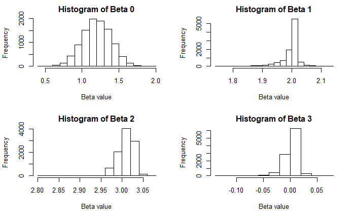

|  | Beta0 | Beta1 | Beta2 | Beta3 |
| --- | --- | --- | --- | --- |
| Lower Bound | 0.823674419951295 | 1.90676806673836 | 2.97011593266341 | -0.0346550900357965 |
| Upper Bound | 1.56995377339942 | 2.04205456756995 | 3.03880108248321 | 0.0209281077799216 |

```r
set.seed(1267)
n <- 200
x <- 1/cbind(1,rt(n,df=1),rt(n,df=1),rt(n,df=1))
beta <- c(1,2,3,0)
y <- x %*% beta + rnorm(100,sd=3)
bootbeta <- matrix(NA,nrow = 10000,ncol = 4)
pr4.times <-system.time({
  registerDoParallel(cores = 3)
  bootloop <- foreach(b = 1:10000, .combine = "c") %do% {
    bootid <- sample(1:200, 200, replace=T)
    bootx <- x[bootid,]
    booty <- y[bootid]
    bootbeta[b,] <- coef(lm(booty~0+bootx))
}
})
stopImplicitCluster()
CI95beta <- matrix(nrow=2, ncol=4)
# CI95betalower <- CI95beta[1]
# CI95betaupper <- CI95beta[2]
par(mfrow=c(2,2))
for(i in 1:4){
  hist(bootbeta[,i], main =
         paste("Histogram of Beta",i-1), xlab = "Beta value")
  CI95beta[,i] <- quantile(bootbeta[,i], prob=c(.025, .975))
}
colnames(CI95beta) <- c("Beta0", "Beta1", "Beta2", "Beta3")
knitr::kable(cbind(c("Lower Bound", "Upper Bound"), CI95beta), caption="95% Confidence Intervals for Each Beta Value via Bootstrapping")

pr4.times
```

```
   user  system elapsed
  13.89    0.00   14.56
```

```r
#colnames(pr4.times) <- c("User","System","Elapsed","User Child", "System Child")
# pr4.times.tbl <- as_tibble(pr4.times)
#knitr::kable(cbind(c("Times"),pr4.times), col.names = c("User","System","Elapsed"),  caption = "Run Time for Problem 4")
```

# Appendix 1: R code

```r
set.seed(1256)
theta <- as.matrix(c(1, 2), nrow = 2)
X <- cbind(1, rep(1:10, 10))
h <- X %*% theta + rnorm(100, 0, 0.2)

theta_current <- as.matrix(c(0, 0), nrow = 2)
theta_new <- as.matrix(c(1, 1), nrow = 2)
alpha <- 1e-04
tolerance <- 1e-06
m <- length(h)
tX <- t(X)

# initialize ten pairs for theta that will be run in parallel
theta_grid <- matrix(c(rep(0, 10), seq(0, 4.5, by = 0.5)), nrow = 2, ncol = 10,
    byrow = T)

registerDoRNG()
cl <- makePSOCKcluster(rep("localhost", 3))
registerDoParallel(cl)
theta_new_mat <- matrix(NA, nrow = 10, ncol = 2)
theta_exp <- foreach(i = 1:10, .combine = "cbind") %dopar% {
    theta_current <- theta_grid[, i]
    theta_new <- theta_current + 10 * tolerance
    while (sum(abs(theta_new - theta_current) > tolerance) | i < 2e+05) {
        i <- i + 1
        theta_current <- theta_new
        theta_grad <- tX %*% ((X %*% theta_current) - h)
        theta_new <- theta_current - alpha/m * theta_grad
        # theta_exp <<- theta_new
    }
    return(theta_new)
    knitr::kable(cbind(c("Theta0", "Theta1"), round(theta_exp, 6)), col.names = c("Theta Grid Col #:",
        "1", "2", "3", "4", "5", "6", "7", "8", "9", "10"))

}
stopCluster(cl)

# PROBLEM 4: Bootstrap
set.seed(1267)
n <- 200
x <- 1/cbind(1, rt(n, df = 1), rt(n, df = 1), rt(n, df = 1))
beta <- c(1, 2, 3, 0)
y <- x %*% beta + rnorm(100, sd = 3)

bootbeta <- matrix(NA, nrow = 10000, ncol = 4)

pr4.times <- system.time({
    registerDoParallel(cores = 3)
    bootloop <- foreach(b = 1:10000, .combine = "c") %do% {
        bootid <- sample(1:200, 200, replace = T)
        bootx <- x[bootid, ]
        booty <- y[bootid]

        bootbeta[b, ] <- coef(lm(booty ~ 0 + bootx))
    }
})
stopImplicitCluster()

CI95beta <- matrix(nrow = 2, ncol = 4)
# CI95betalower <- CI95beta[1] CI95betaupper <- CI95beta[2]

par(mfrow = c(2, 2))
for (i in 1:4) {
    hist(bootbeta[, i], main = paste("Histogram of Beta", i - 1), xlab = "Beta value")
    CI95beta[, i] <- quantile(bootbeta[, i], prob = c(0.025, 0.975))

}

colnames(CI95beta) <- c("Beta0", "Beta1", "Beta2", "Beta3")
knitr::kable(cbind(c("Lower Bound", "Upper Bound"), CI95beta), caption = "95% Confidence Intervals for Each Beta Value via Bootstrapping")
pr4.times
# colnames(pr4.times) <- c('User','System','Elapsed','User Child', 'System
# Child') pr4.times.tbl <- as_tibble(pr4.times)
# knitr::kable(cbind(c('Times'),pr4.times), col.names =
# c('User','System','Elapsed'), caption = 'Run Time for Problem 4')
```